# DATA 201: Week 14 Neural Network Exercise

## MNIST Handwritten digit classifier

For this in-class exercise we will look at the MNIST handwritten digit dataset and classify them using different types of neural networks using keras and tensorflow.

### Homework

- Choose at least one dataset to train a new NN Classifier on
- Describe why you chose your model
- Describe any difficulties you had in training your neural network

### Requirements:

- You should show the accuracy of your model
- You should use markdown appropriately for annotating your code and answering the questions above
- Your jupyter notebook should be committed to gitlab after you go to kernel and "Restart kernel and run all"

### Imports and style

```python
from tensorflow.keras.datasets import mnist
from tensorflow import keras
from tensorflow.keras import layers
import tensorflow as tf
import os
os.environ['TF_CPP_MIN_LOG_LEVEL'] = '3'

import pandas as pd
import matplotlib.pyplot as plt
height = 5
plt.rcParams["figure.figsize"] = [1.618*height, height]
plt.style.use("seaborn")
```

### Load the MNIST data into a NumPy arrays

```python
from tensorflow.keras.datasets import mnist
(train_images, train_labels), (test_images, test_labels) = mnist.load_data()
```

```python
train_images.shape
```

```
(60000, 28, 28)
```

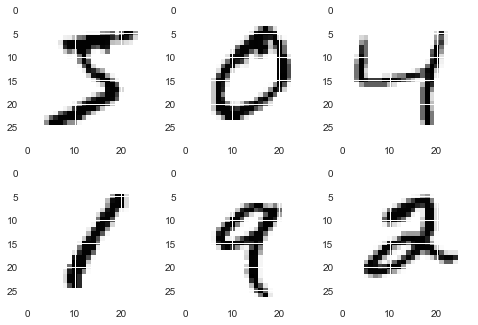

```python
n_rows = 2
n_cols = 3
fig, ax = plt.subplots(n_rows, n_cols)
for row in range(n_rows):
    for col in range(n_cols):
        ax[row, col].imshow(train_images[row*n_cols + col])
```

```python
train_labels[:6]
```

```
array([5, 0, 4, 1, 9, 2], dtype=uint8)
```

### Build Keras Model

```python
model = keras.Sequential()
model.add(layers.Dense(1024, "relu"))
model.add(layers.Dense(1024, "relu"))
model.add(layers.Dense(1024, "relu"))
model.add(layers.Dense(10, activation="softmax"))
```

```python
print(tf.config.list_physical_devices())
```

```
[PhysicalDevice(name='/physical_device:CPU:0', device_type='CPU')]
```

```python
model.compile(optimizer="adam",
             loss="sparse_categorical_crossentropy",
             metrics=["accuracy"])
```

### Preppring data for MLP Model (flattening)

```python
train_images.shape
```

```
(60000, 28, 28)
```

```python
flat_train_images = train_images.reshape((60000, 28*28))
flat_train_images = flat_train_images.astype("float32")/255
flat_test_images = test_images.reshape((10000, 28*28))
flat_test_images = flat_test_images.astype("float32")/255
```

```python
flat_train_images.shape
```

```
(60000, 784)
```

```python
flat_test_images.shape
```

```
(10000, 784)
```

```python
# model.fit(flat_train_images, train_labels, epochs=50, batch_size=128)
```

### Evaluate the model

```python
model.evaluate(flat_test_images, test_labels)
```

```
[2.3098766803741455, 0.10109999775886536]
```

```python
cnn_model = keras.Sequential()
cnn_model.add(layers.Conv2D(filters=16, kernel_size=(7,7), activation="relu"))
cnn_model.add(layers.Conv2D(filters=8, kernel_size=(5,5), activation="relu"))
cnn_model.add(layers.Flatten())

cnn_model.add(layers.Dense(2048, activation="relu"))
cnn_model.add(layers.Dense(2048, activation="relu"))
cnn_model.add(layers.Dense(2048, activation="relu"))
cnn_model.add(layers.Dense(10, activation="softmax"))

cnn_model.compile(optimizer="adam",
             loss="sparse_categorical_crossentropy",
             metrics=["accuracy"])
```

```python
reshaped_train_images = train_images.reshape(60000, 28, 28, -1)/255.0
reshaped_test_images = test_images.reshape(10000, 28, 28, -1)/255.0
```

```python
reshaped_train_images.shape
```

```
(60000, 28, 28, 1)
```

```python
cnn_model.fit(reshaped_train_images, train_labels, epochs=10, batch_size=64)
```

```
<keras.callbacks.History at 0x155d20430>
```

### Check accuracy using test data

```python
cnn_model.evaluate(reshaped_test_images, test_labels)
```

```
[0.06691259890794754, 0.9879999756813049]
```

## My own Dataset: Learning Poker Hands

```python
url = 'http://archive.ics.uci.edu/ml/machine-learning-databases/poker/poker-hand-testing.data'
```

```python
cols = ["Suit of card #1", "Rank of card #1","Suit of card #2", "Rank of card #2", "Suit of card #3", "Rank of card #3", "Suit of card #4", "Rank of card #4", "Suit of card #5", "Rank of card 5", "Poker Hand"]
```

```python
Poker_Data = pd.read_csv(url, names = cols)
```

```python
data = Poker_Data.drop(["Poker Hand"], axis=1)
labels = Poker_Data["Poker Hand"]
```

```python
min(labels)
```

```
0
```

```python
max(labels)
```

```
9
```

```python
data
```

|  | Suit of card #1 | Rank of card #1 | Suit of card #2 | Rank of card #2 | Suit of card #3 | Rank of card #3 | Suit of card #4 | Rank of card #4 | Suit of card #5 | Rank of card 5 |
| --- | --- | --- | --- | --- | --- | --- | --- | --- | --- | --- |
| 0 | 1 | 1 | 1 | 13 | 2 | 4 | 2 | 3 | 1 | 12 |
| 1 | 3 | 12 | 3 | 2 | 3 | 11 | 4 | 5 | 2 | 5 |
| 2 | 1 | 9 | 4 | 6 | 1 | 4 | 3 | 2 | 3 | 9 |
| 3 | 1 | 4 | 3 | 13 | 2 | 13 | 2 | 1 | 3 | 6 |
| 4 | 3 | 10 | 2 | 7 | 1 | 2 | 2 | 11 | 4 | 9 |
| ... | ... | ... | ... | ... | ... | ... | ... | ... | ... | ... |
| 999995 | 3 | 1 | 1 | 12 | 2 | 9 | 4 | 9 | 2 | 6 |
| 999996 | 3 | 3 | 4 | 5 | 2 | 7 | 1 | 4 | 4 | 3 |
| 999997 | 1 | 11 | 4 | 7 | 3 | 9 | 1 | 13 | 2 | 7 |
| 999998 | 3 | 11 | 1 | 8 | 1 | 1 | 3 | 13 | 2 | 8 |
| 999999 | 2 | 5 | 2 | 9 | 4 | 9 | 2 | 3 | 3 | 3 |

1000000 rows × 10 columns

```python
from sklearn.model_selection import train_test_split
data_train, data_test, label_train, label_test = train_test_split(data, labels, random_state=0)
```

```python
data_train.shape
```

```
(750000, 10)
```

```python
Pk_model = keras.Sequential()
Pk_model.add(layers.Dense(1024, "relu"))
Pk_model.add(layers.Dense(1024, "relu"))
Pk_model.add(layers.Dense(1024, "relu"))
Pk_model.add(layers.Dense(10, activation="softmax"))
```

```python
Pk_model.compile(optimizer="adam",
             loss="sparse_categorical_crossentropy",
             metrics=["accuracy"])
```

## Accuracy of the Model

```python
Pk_model.evaluate(data_train, label_train)
```

```
[2.4387247562408447, 0.06139066815376282]
```

-Why did I choose this model? I chose to do poker hands because of the massive amount of combinations a deck of cards can create, so I thought it would be really cool to see a model learn how to identify hands.

I had some difficulties not in the model, but when trying to train on my desktop at home I couldnt switch between using my CPU and GPU. It ended up taking a while with the CPU and I wanted to see how fast i could go with the GPU